# Medicines in the kitchen: Gender roles shape ethnobotanical knowledge in Marrakshi households

Vincent Manzanilla - Irene Teixidor https://github.com/vincentmanz (BaseClear B.V / DataLabs)  
2021-08-11

## Authors

Irene Teixidor-Toneu1, Sara Elgadi2, Hamza Zine2, Vincent Manzanilla3, Ahmed Ouhammou2, Ugo D’Ambrosio4,5

1 Natural History Museum, University of Oslo, Norway  
2 Laboratory of Microbial Biotechnology, Agrosciences and Environment, Regional Herbarium ‘MARK’, Faculty of Sciences Semlalia, Cadi Ayyad University, Marrakech 40000, Morocco; sara.elgadi@ced.uca.ma (S.E.); hamza.zine@edu.uca.ma (H.Z.)  
3 Baseclear BV, 2333 Leiden, Netherlands.  
4 Global Diversity Foundation (GDF), 37 St. Margaret’s Street, Canterbury CT1 2TU, Kent, UK  
5 Etnobioﬁc Research Group- Universitat de Barcelona and Institut Botànic de Barcelona (IBB-CSIC-ICUB), Barcelona, Spain

## Abstract

Differences in knowledge about plants across genders are contingent to specific cultural domains, yet the boundaries between food and medicine are blurred and it is unclear if and how gender plays a role in creating such continuum. Here, we present an in-depth evaluation of the links between gender, medicinal plant knowledge, and culinary culture in Marrakech, Morocco. We interviewed 30 women and 27 men with different socio-demographic characteristics and evaluated how gender and cooking frequency shape their food and medicinal plant knowledge. We documented 171 ethno-taxa used in Marrakshi households as food, medicine or both, corresponding to 148 botanical taxa and three mixtures. While no clear differences appear in food plant knowledge by gender, women have a three-fold greater knowledge of medicinal plants, as well as plants with both ambivalent uses. Women’s medicinal and food plant knowledge increases with their reported frequency of cooking, whereas the opposite trend is observed among men. The profound relations between the culinary and health domains are mediated through gender.

**KEYWORDS:** Food-medicine continuum; functional foods; gastronomy; Marrakech; Morocco; pharmacopeia; spices; women’s knowledge.

## Code

```r
library(dplyr)
library(tidyr)
library(hrbrthemes)
library(ggplot2)
library(viridis)
```

```r
file <- read.csv("i-Marrakech_dataset.csv", sep=";")
df0 <- file %>% select(Sex,N_Pl_total, Freq_cooking ) %>%
  mutate(Sex, Gender = case_when(
    Sex == "F" ~ "Women",
    Sex == "M" ~ "Men"))
```

### Linear model

```r
model1 <-
  glm(df0$N_Pl_total ~ df0$Gender * df0$Freq_cooking,
      family = quasipoisson,
      data = df0)
summary(model1)
```

```
Call:
glm(formula = df0$N_Pl_total ~ df0$Gender * df0$Freq_cooking,
    family = quasipoisson, data = df0)

Deviance Residuals:
    Min       1Q   Median       3Q      Max
-4.3759  -0.8626   0.1052   0.5373   3.2488

Coefficients:
                                  Estimate Std. Error t value
(Intercept)                       3.523309   0.061269  57.506
df0$GenderWomen                   0.064729   0.134305   0.482
df0$Freq_cooking                 -0.019707   0.007963  -2.475
df0$GenderWomen:df0$Freq_cooking  0.042147   0.009751   4.322
                                 Pr(>|t|)
(Intercept)                       < 2e-16 ***
df0$GenderWomen                    0.6318
df0$Freq_cooking                   0.0166 *
df0$GenderWomen:df0$Freq_cooking 6.84e-05 ***
---
Signif. codes:  0 '***' 0.001 '**' 0.01 '*' 0.05 '.' 0.1 ' ' 1

(Dispersion parameter for quasipoisson family taken to be 1.989494)

    Null deviance: 372.48  on 56  degrees of freedom
Residual deviance: 107.25  on 53  degrees of freedom
AIC: NA

Number of Fisher Scoring iterations: 4
```

### General overview

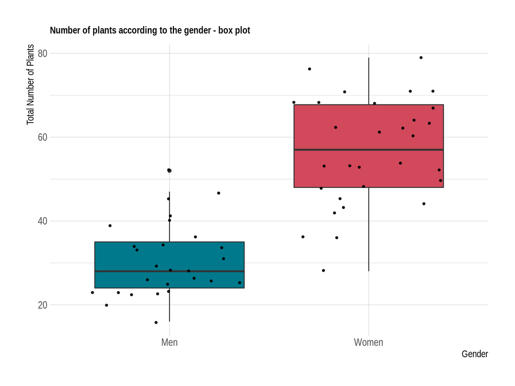

```r
df0 %>%
  ggplot(aes(x = Gender, y = N_Pl_total, fill = Gender)) +
  geom_boxplot(fill=c( "#00798c",  "#d1495b")) +
  geom_jitter(color = "black",
              size = 0.9,
              alpha = 0.9) +
  theme_ipsum(axis_title_size = 11) +
  theme(legend.position = "none",
        plot.title = element_text(size = 11)) +
  ylab("Total Number of Plants") +
  xlab("Gender") +
  ggtitle("Number of plants according to the gender - box plot")
```

### GLM prediction of number of plants according to frequency of cooking per men and women

```r
x <- seq(0, 28, 1)
men_coeff <- 3.588038 - 0.0197708 * x
women_coeff <- 3.588038 + 0.022439 * x
Men <- exp(men_coeff)
Women <- exp(women_coeff)

plants <- data.frame(x, Men, Women)
plants_long <- plants %>%
  pivot_longer(!x, names_to = "Gender", values_to = "coeff")
```

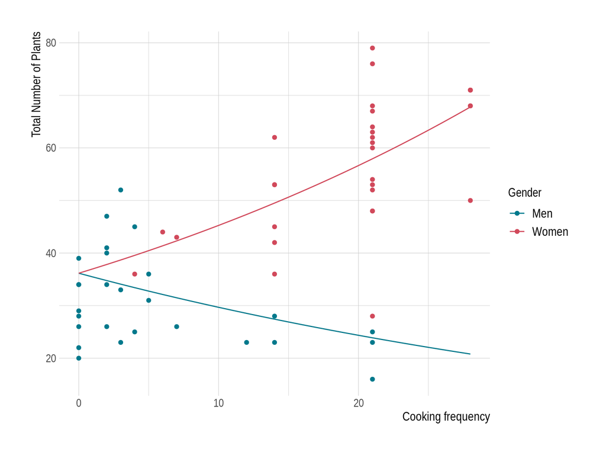

```r
ggplot() +
  geom_point(data = df0, aes(x = Freq_cooking, y = N_Pl_total, color = Gender)) +
  geom_line(data = plants_long, aes(x, coeff, color= Gender))  +
  xlab("Cooking frequency") +
  ylab("Total Number of Plants") +
  theme_ipsum(axis_title_size = 12, axis_text_size = 11) + theme(legend.text = element_text(size = 12)) +
  scale_color_manual(values = c( "#00798c",  "#d1495b", "#00798c","#d1495b"))
```

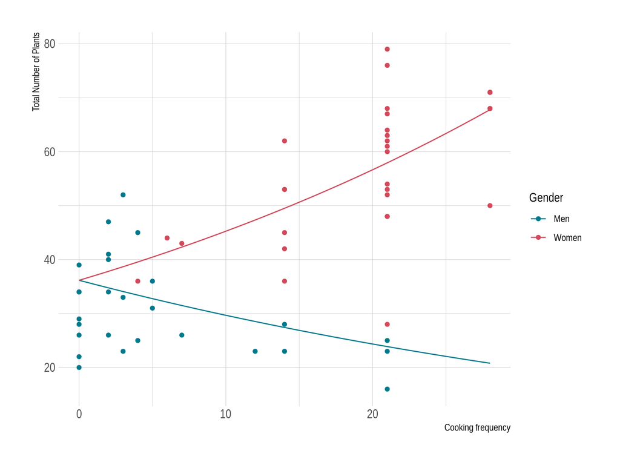

```r
ggsave("Figure_1_font_big.png")


ggplot() +
  geom_point(data = df0, aes(x = Freq_cooking, y = N_Pl_total, color = Gender)) +
  geom_line(data = plants_long, aes(x, coeff, color= Gender))  +
  xlab("Cooking frequency") +
  ylab("Total Number of Plants") +
  theme_ipsum() +
  scale_color_manual(values = c( "#00798c",  "#d1495b", "#00798c","#d1495b"))
```

```r
ggsave("Figure_1_font_small.png")
```

*Figure 2. Number of elicited items according to frequency of cooking (number of times that the participant prepares a meal per week) per men and women. Trends are based on the GLM with interactions (see full model and results in ESM4).*